# Los Numeros Estan Guaya

Alberto Vasquez

## Introduccion

Este analysis fue inspirado por el libro *“How Charts Lie”* o *“Como Mienten Los Graficos”* de el Data Scientist nacido en España **Alberto Cairo**. Alberto Cairo es el Knight Chair in Visual Journalism at the School of Communication de la Universidad de Miami. Esta es una quote de su libro:

> Hoy, las conversaciones públicas están cada vez más impulsadas por números. Si bien los gráficos, las infografías y los diagramas pueden hacernos más inteligentes, también pueden engañar, intencional o involuntariamente. Para ser ciudadanos informados, todos debemos ser capaces de decodificar y utilizar la información visual que los políticos, periodistas e incluso nuestros empleadores nos presentan cada día.

Es por esto que decidi nombrar este analysis *Los Numeros Estan Guaya* por **Alberto Vasquez**

## Objetivo

He visto como las noticias y las redes sociales usan los numeros del virus y solo dicen lo que se ve mas impactante para hacer mas buya y generar mas vistas a su canal o su pagina. En esta analysis demustro con numeros reales como los medios de comunicacion manipulan la informacion para meter miedo a la poblacion. Veremos no solo los numeros de nuevos casos diarios pero tambien de cuantos examenes y cuantas muertes diarias han habido, como se relacionan y los radio de cada uno.

### Estados Unidos

#### Correlación

La correlacion es *una relación o conexión mutua entre dos o más cosas.* En este caso veremos que tan fuerte es la correlacion entre los casos diarios y las pruebas diarias. Una correlacion de 0 es baja y una correlacion cercana a 1 es alta

La correlacion entre casos diarios y pruebas diarias es de 0.7510963

#### Graficos

##### Los Graficos que muestran

Este es un ejemplo de los graficos que muestran en las noticias

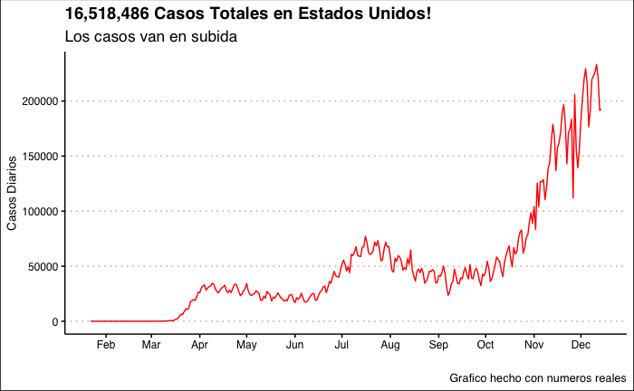

##### Los Graficos que NO muestran

Esto es lo que no dicen en las noticias.  
Y de nuevo, esto no me lo estoy inventando yo, estos numeros son tomados de fuentes confiables.

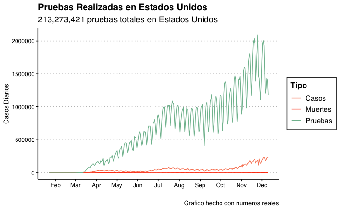

**Que nos muestran estos graficos?**

El Numero de pruebas realizadas es mucho mayor al numero de casos lo que indica que la propagacion del virus no es muy alta.

#### Proporciones

Ahora veremos las proporciones entre pruebas y casos y entre casos y muertes.

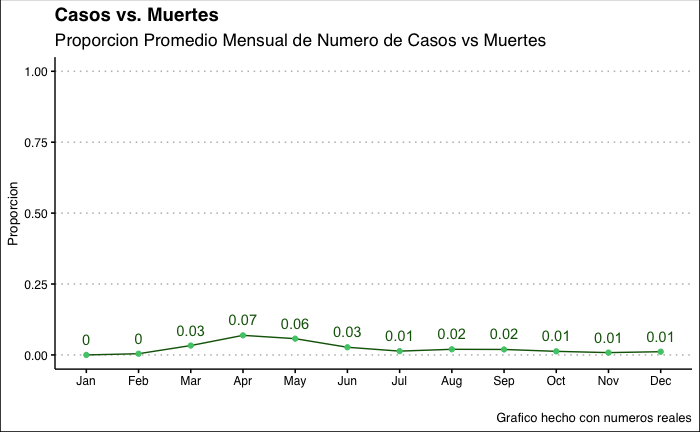

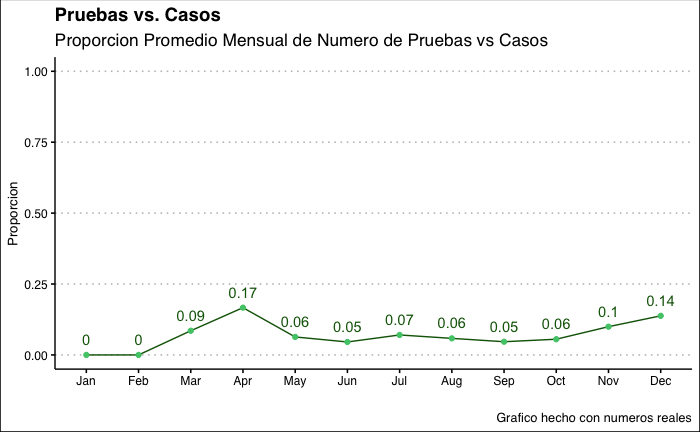

El dia con mas casos confirmados, se dijo que hubieron *229,531* casos, pero lo que no se dijo que ese dia se hicieron *2,098,517* pruebas.  
Lo que significa que ese dia la proporcion fue de **0.11**

### El Salvador

**NOTA:** Para mi que despues de Septiembre en El Salvador la recollecion de datos se distoriciono bastante.

#### Correlación

La correlacion es *una relación o conexión mutua entre dos o más cosas.* En este caso veremos que tan fuerte es la correlacion entre los casos diarios y las pruebas diarias. Una correlacion de 0 es baja y una correlacion cercana a 1 es alta

La correlacion entre casos diarios y pruebas diarias es de 0.4496156

#### Graficos

##### Los Graficos que muestran

Este es un ejemplo de los graficos que muestran en las noticias

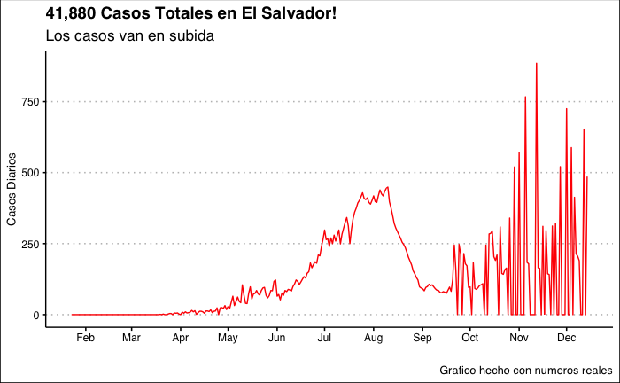

##### Los Graficos que NO muestran

Esto es lo que no dicen en las noticias.  
Y de nuevo, esto no me lo estoy inventando yo, estos numeros son tomados de fuentes confiables.

[figure not shown]

**Que nos muestran estos graficos?**

El Numero de pruebas realizadas es mucho mayor al numero de casos lo que indica que la propagacion del virus no es muy alta.

#### Proporciones

Ahora veremos las proporciones entre pruebas y casos y entre casos y muertes.

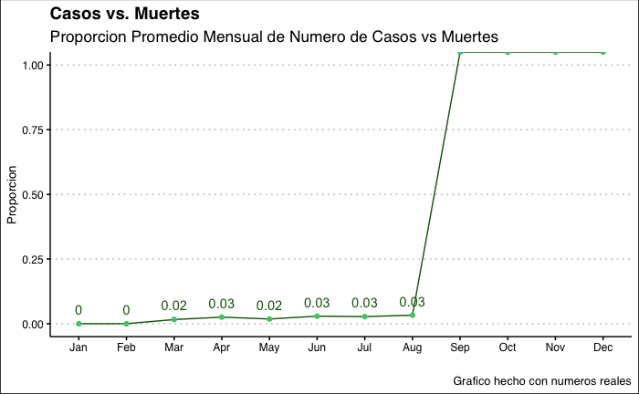

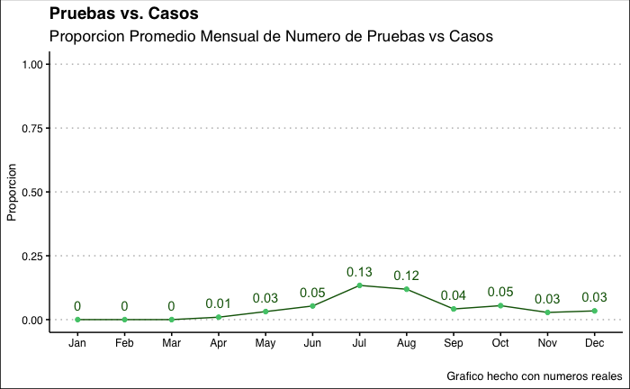

El dia con mas casos confirmados, se dijo que hubieron *885* casos, pero lo que no se dijo que ese dia se hicieron *5,498* pruebas.  
Lo que significa que ese dia la proporcion fue de **0.16**

### España

#### Correlación

La correlacion es *una relación o conexión mutua entre dos o más cosas.* En este caso veremos que tan fuerte es la correlacion entre los casos diarios y las pruebas diarias. Una correlacion de 0 es baja y una correlacion cercana a 1 es alta

La correlacion entre casos diarios y pruebas diarias es de 0.8560119

#### Graficos

##### Los Graficos que muestran

Este es un ejemplo de los graficos que muestran en las noticias

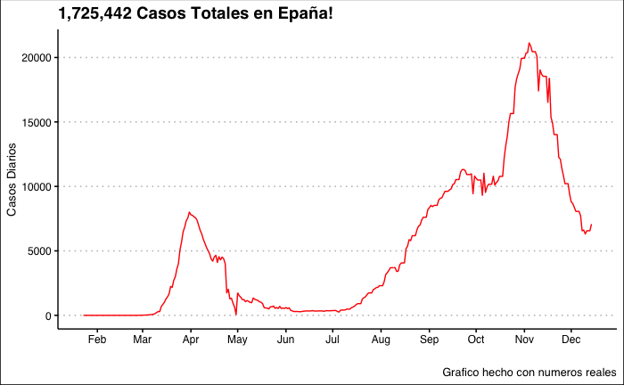

##### Los Graficos que NO muestran

Esto es lo que no dicen en las noticias.  
Y de nuevo, esto no me lo estoy inventando yo, estos numeros son tomados de fuentes confiables.

[figure not shown]

**Que nos muestran estos graficos?**

El Numero de pruebas realizadas es mucho mayor al numero de casos lo que indica que la propagacion del virus no es muy alta.

#### Proporciones

Ahora veremos las proporciones entre pruebas y casos y entre casos y muertes.

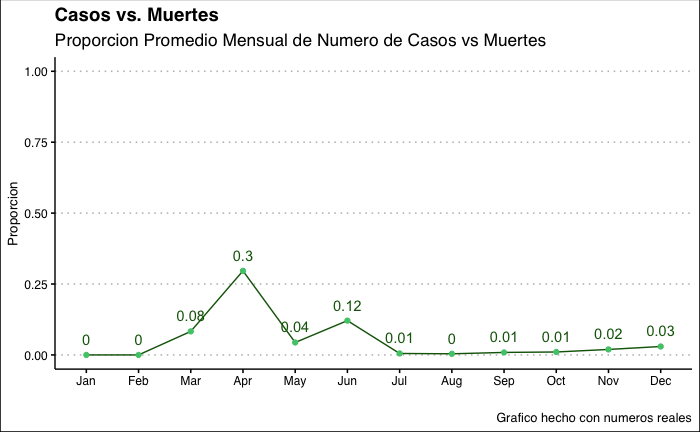

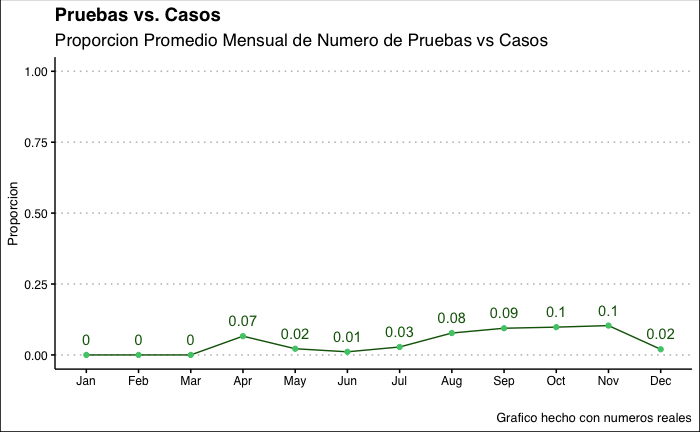

El dia con mas casos confirmados, se dijo que hubieron *21,129* casos, pero lo que no se dijo que ese dia se hicieron *168,782* pruebas.  
Lo que significa que ese dia la proporcion fue de **0.13**